# CA2 Growth of Digital Games

2025-04-02

# Introduction

The gaming industry has experienced a massive growth over the past few decades, with the rise of Steam playing a pivitol role in shaping how games are published and distributed. Steam hosts a large library of games spanning over 90,000 with many genres, developers and price points. With this vast choice for players and developers understanding the trends and patterns in the data can be beneficial for both parties. This report leverages the Steam Games Dataset 2025 which includes all key information such as release dates, genre tags, developer and publisher information, and user reviews. The dataset is used to explore the growth of digital games on Steam and to identify the key trends and patterns in the data.In this report I will be exploring these trends using visualisation techniques in R, examples of things I will explore are how pricing can effect user reviews and how certain genres have grown and become more dominant over time. The findings will show a broader understanding of how game developers and publishers strategise their releases and how the pricing model may impact player perception and how the genre lines up with current trends. This report will provide meaningful insights for game developers and publishers to make informed decisions on their game releases and marketing strategies.

# Research Questions / Rational

## 1. How does the frequeny / number of DLC’s for a game effect user reviews?

Some developers focus on keeping their games running for years by adding gameplay mechanics with regular updates and DLC I want to investigate if this has a positive or negative effect on user reviews. I aim to see if the number of DLC’s released for a game has an impact on the user reviews and how this has changed over time. I think this is interesting as some players may feel that the game is being milked for money and that the DLC’s should have been included in the base game. By analysing this data I can see how the number of DLC’s has impacted the user reviews.

## 2. How does the pricing of games affect user reviews?

The price of games has always been a crucial factor in players decision making when buying a game but in this research question I want to figure out how the pricing of games affects user reviews. I aim to see if there is a correlation between the price of games and the user reviews and how this has changed over time. I think this is interesting as higher priced games tend to be reviewed more harshly by players due to the higher expectations they have for the game. Players could also be more forgiving of lower priced games as they are more likely to take a chance on a cheaper game. By analysing this data I can see how the pricing of games has impacted the user reviews.

## 3. What genres have had trending growth over the years?

The third research question aims to understand what genres have had trending growth over the years. I aim to see if certain genres have become more popular over time and how this has impacted the sales of games in those genres. This is important as it can help developers and publishers understand what genres are popular and how they can capitalise on this trend. I want to analyse the number of releases per genre and see how this has changed over time by picking a few popular genres and seeing how they have grown over the years compared to other genres.

## 4. How has the AAA landscape changed over the years?

The fourth research question aims to understand how the AAA landscape has changed over the years. I aim to see how the number of AAA games has increased over time and how this has impacted the sales of games in this category. I also want to examine the price increase of these games and the user reviews since these price changes have come into effect.I want to understand the shift in the AAA landscape and see how the evolution of these studios and game quality with regular price increases has changed the publics opinion of AAA games and studios.

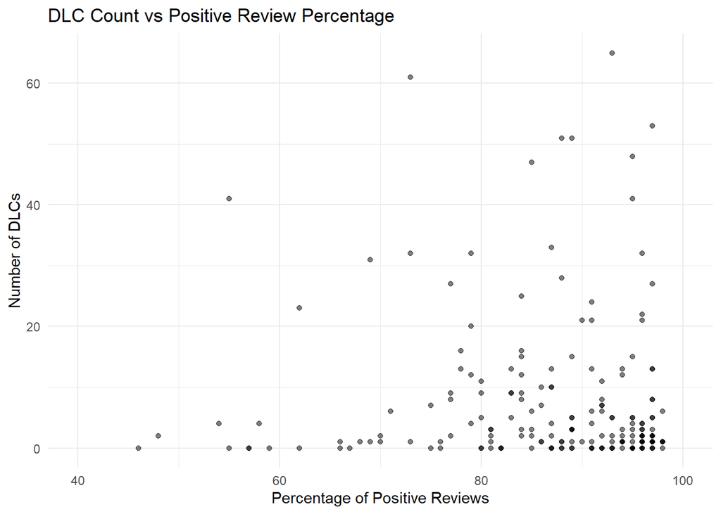

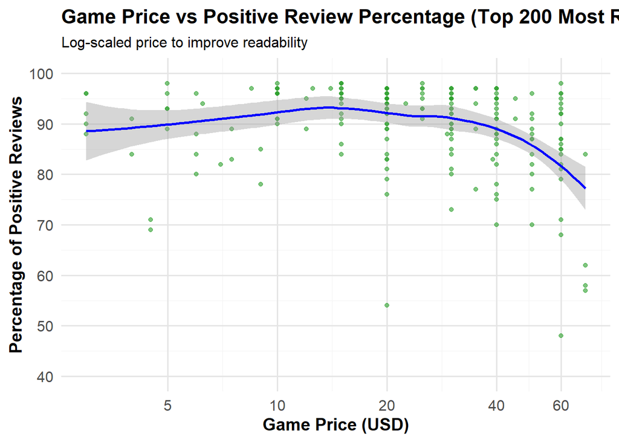

# How does the pricing of games affect user reviews?

Taking a deeper dive into the meaning of this graph I can see that there is a non-linear relationship between the price of games and the percentage of positive reviews. The graph shows the very cheap games have a slightly lower positive percentage than the games in the range of about 20-30. But we also see as games get above this range players seem to be more harsh in the reviews as I think that these players have a higher expectation of the game based on the price that they paid. We can also see that there is outliers among the data as there is low rated games in in all ranges which shows that no matter the price games can be rated low. But in general we have seen that the price of games does have an impact on player perception and forgiveness for flaws within games.

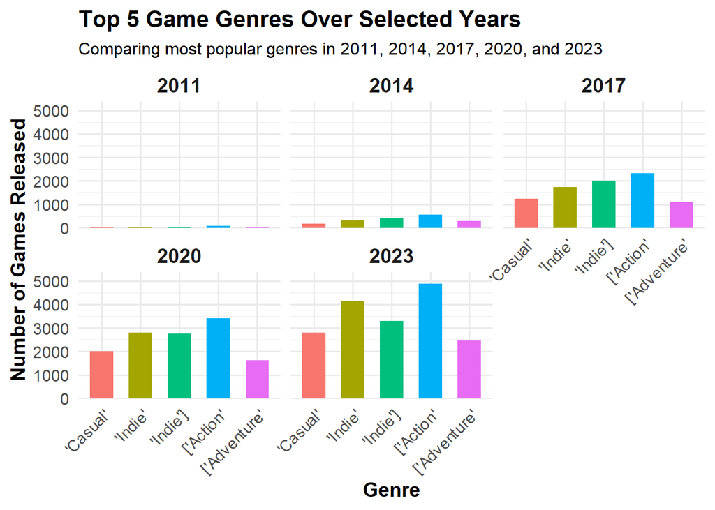

[figure not shown]

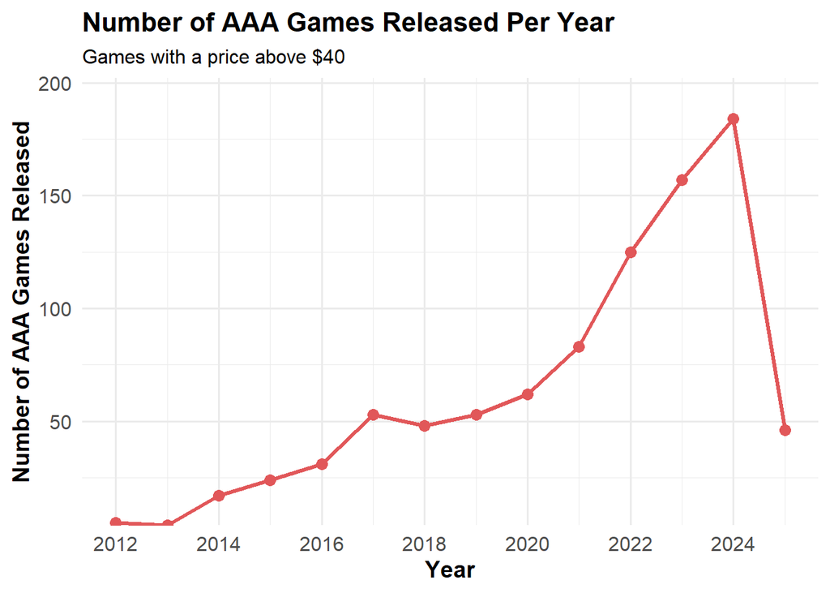

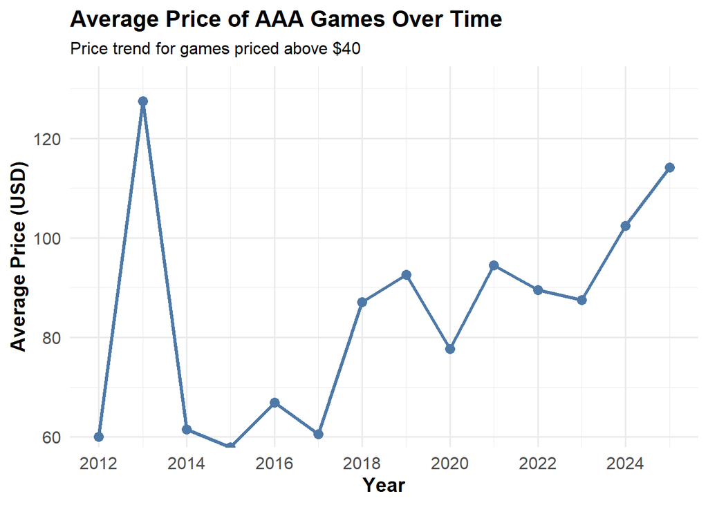

```
## [1] "appid"        "name"         "release_year" "price"        "genres"
```

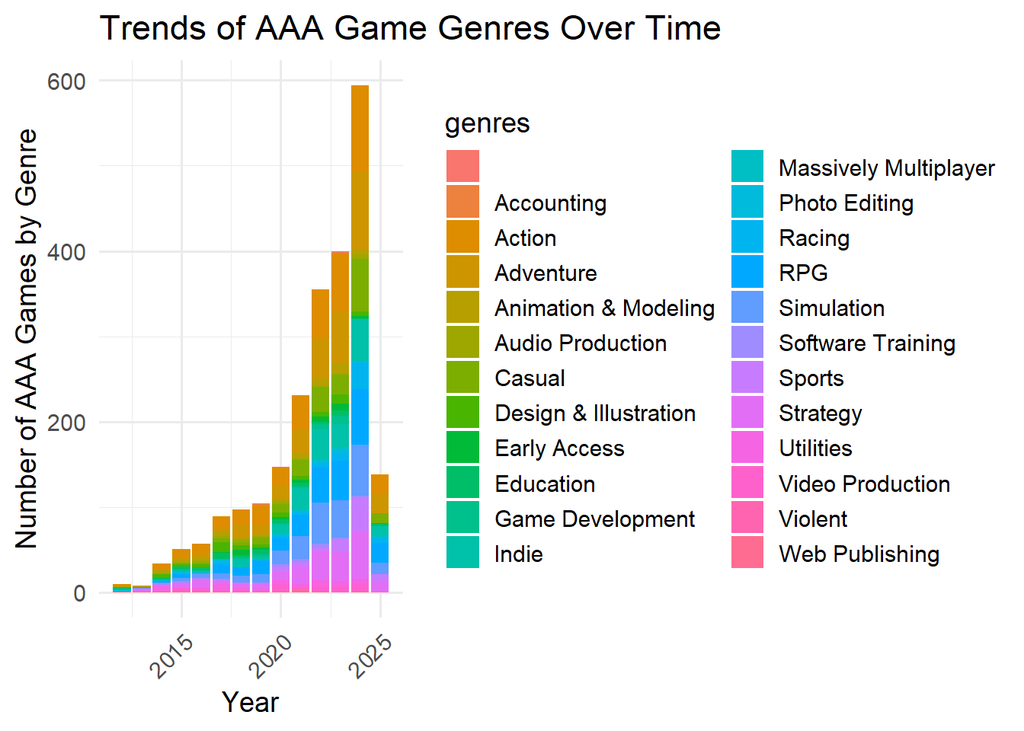